# Lab 4 · Impacto: ¿cambian tus KPIs al limpiar?

Desaprendiendo sobre… Limpieza de datos · Estudiante_18 (sector Servicios)

> **Objetivo.** Limpiar no es un fin: sirve para que **las cifras que das sean defendibles**. Calculamos los mismos KPIs con cuatro niveles de limpieza y comprobamos cuánto se mueve cada uno. Es el «tres personas, tres cifras» de la parte de gobierno, pero con datos de verdad.

```r
# ── Preparación (ejecutar una vez) ───────────────────────────────────────────
# En Colab/Linux usamos binarios precompilados: los paquetes se instalan en segundos.
if (Sys.info()[["sysname"]] == "Linux")
  options(repos = c(CRAN = "https://packagemanager.posit.co/cran/__linux__/jammy/latest"))

paquetes <- c("tidyverse")
faltan <- paquetes[!vapply(paquetes, requireNamespace, logical(1), quietly = TRUE)]
if (length(faltan)) install.packages(faltan)
suppressPackageStartupMessages({
library(tidyverse)
})

# Los datos: si no están en la carpeta, se descargan
BASE_URL <- "https://raw.githubusercontent.com/vicentcorrecher/lab-limpieza-datos/main/datos"
obtener <- function(f) {
  ruta <- file.path("datos", f)
  if (!file.exists(ruta)) {
    dir.create(dirname(ruta), recursive = TRUE, showWarnings = FALSE)
    download.file(paste0(BASE_URL, "/", f), ruta, quiet = TRUE, mode = "wb")
  }
}
for (f in c(
  "funciones_labs.R",
  "estudiante_18/operaciones.csv",
  "estudiante_18/clientes.csv",
  "estudiante_18/productos_servicios.csv",
  "estudiante_18/sedes.csv",
  "estudiante_18/campanas.csv"
)) obtener(f)
source("datos/funciones_labs.R")
```

```r
d <- cargar_e18()
```

## 1. Cuatro escenarios

[output not shown]

```r
escenarios <- list(
  "A · Bruto"       = d$operaciones,
  "B · Prudente"    = limpiar_e18(d)$operaciones,
  "C · Sin pre-alta" = limpiar_e18(d, excluir = "antes_alta")$operaciones,
  "D · Estricto"    = limpiar_e18(d, excluir = c("antes_alta", "margen_negativo", "sector"))$operaciones)

tabla <- imap_dfr(escenarios, \(ops, nombre) kpis(ops) |> mutate(escenario = nombre, .before = 1))
tabla |> mutate(across(where(is.numeric), \(x) round(x, 2)))
```

```
# A tibble: 4 × 9
  escenario        operaciones ingresos   margen margen_pct ticket_medio
  <chr>                  <dbl>    <dbl>    <dbl>      <dbl>        <dbl>
1 A · Bruto              19008 2576707. 1088843.       42.3         136.
2 B · Prudente           19000 2575635. 1088351.       42.3         136.
3 C · Sin pre-alta       17042 2302826.  972902.       42.2         135.
4 D · Estricto           16767 2277989.  967324.       42.5         136.
# ℹ 3 more variables: satisfaccion_media <dbl>, tasa_incidencia <dbl>,
#   pct_margen_negativo <dbl>
```

## 2. ¿Cuánto se mueve cada KPI respecto al dato bruto?

```r
variacion <- tabla |>
  pivot_longer(-escenario, names_to = "kpi", values_to = "valor") |>
  group_by(kpi) |>
  mutate(variacion_pct = round(100 * (valor / valor[escenario == "A · Bruto"] - 1), 2)) |>
  ungroup()

variacion |> select(-valor) |> pivot_wider(names_from = escenario, values_from = variacion_pct)
```

```
# A tibble: 8 × 5
  kpi               `A · Bruto` `B · Prudente` `C · Sin pre-alta` `D · Estricto`
  <chr>                   <dbl>          <dbl>              <dbl>          <dbl>
1 operaciones                 0          -0.04             -10.3          -11.8
2 ingresos                    0          -0.04             -10.6          -11.6
3 margen                      0          -0.05             -10.6          -11.2
4 margen_pct                  0           0                 -0.02           0.49
5 ticket_medio                0           0                 -0.32           0.22
6 satisfaccion_med…           0           0                  0.02           0.01
7 tasa_incidencia             0           0.04               1.78           1.8
8 pct_margen_negat…           0           0.04               3.14        -100
```

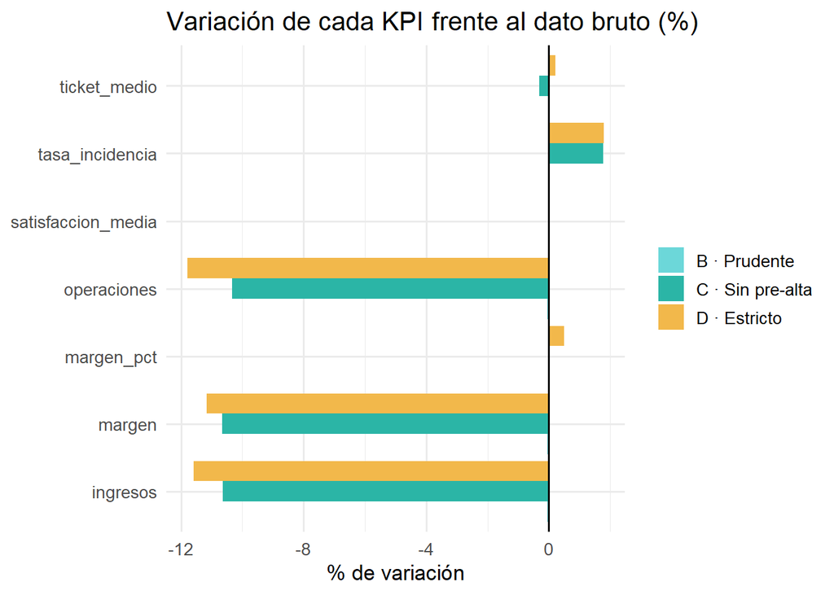

```r
variacion |>
  filter(kpi %in% c("operaciones", "ingresos", "margen", "margen_pct", "ticket_medio", "satisfaccion_media", "tasa_incidencia"),
         escenario != "A · Bruto") |>
  ggplot(aes(kpi, variacion_pct, fill = escenario)) +
  geom_col(position = "dodge") +
  geom_hline(yintercept = 0) +
  coord_flip() +
  scale_fill_manual(values = c("B · Prudente" = "#6CD7D9", "C · Sin pre-alta" = "#2BB5A6", "D · Estricto" = "#F2B84B")) +
  labs(title = "Variación de cada KPI frente al dato bruto (%)", x = NULL, y = "% de variación", fill = NULL) +
  theme_minimal(base_size = 13)
```

### Para pensar

> 1. ¿Qué KPIs **casi no se mueven** y cuáles **se mueven mucho**? ¿Por qué los KPIs que son *medias o ratios* aguantan mejor que los que son *sumas*?
> 2. Si el director pregunta «¿cuánto hemos ingresado?», ¿qué escenario le das? ¿Y si pregunta «¿cuál es nuestro margen?».
> 3. La decisión que más mueve las cifras (descartar operaciones anteriores al alta) es justo la que **no sabemos si es un error**. ¿Qué haces?

## 3. ¿Cambia el ranking de sedes?

```r
ranking <- imap_dfr(escenarios, \(ops, nombre) ops |>
  group_by(sede_id) |> summarise(ingresos = sum(ingresos), .groups = "drop") |>
  mutate(posicion = rank(-ingresos), escenario = nombre)) |>
  select(escenario, sede_id, posicion) |>
  pivot_wider(names_from = escenario, values_from = posicion) |>
  arrange(`A · Bruto`)
ranking
```

```
# A tibble: 9 × 5
  sede_id `A · Bruto` `B · Prudente` `C · Sin pre-alta` `D · Estricto`
  <chr>         <dbl>          <dbl>              <dbl>          <dbl>
1 S004              1              1                  1              1
2 S002              2              2                  3              3
3 S003              3              3                  2              2
4 S005              4              4                  4              4
5 S006              5              5                  5              5
6 S007              6              6                  7              6
7 S008              7              7                  6              7
8 S001              8              8                  8              8
9 S009              9              9                  9              9
```

## 4. Definir el KPI por escrito (la parte que de verdad evita discusiones)

Esta tabla es lo que entregarías junto al cuadro de mando. **Mismo dato, pero cada cifra con su definición y su supuesto**:

```r
tribble(
  ~kpi, ~definicion, ~supuestos_documentados,
  "Ingresos", "Suma de `ingresos` de operaciones únicas", "Se eliminan 8 duplicados exactos; no se excluyen operaciones anteriores al alta",
  "Margen %", "Margen total / ingresos totales (no la media de porcentajes)", "Incluye operaciones con margen negativo (descuentos > 20 %)",
  "Satisfacción media", "Media de respuestas disponibles (1-10)", "Se ignoran 152 vacías (0,8 %), compatibles con ausencia al azar; se informa de n",
  "Tasa de incidencia", "% de operaciones con `incidencia = TRUE`", "Sin supuestos adicionales"
)
```

```
# A tibble: 4 × 3
  kpi                definicion                           supuestos_documentados
  <chr>              <chr>                                <chr>
1 Ingresos           Suma de `ingresos` de operaciones ú… Se eliminan 8 duplica…
2 Margen %           Margen total / ingresos totales (no… Incluye operaciones c…
3 Satisfacción media Media de respuestas disponibles (1-… Se ignoran 152 vacías…
4 Tasa de incidencia % de operaciones con `incidencia = … Sin supuestos adicion…
```

### Toca esto

Define **tu propio escenario**: elige qué excluir y compara con B.

```r
# >>> TOCA AQUÍ: opciones "antes_alta", "antes_lanzamiento", "margen_negativo", "sector" <<<
MI_ESCENARIO <- c("antes_lanzamiento")

bind_rows(
  kpis(escenarios[["B · Prudente"]]) |> mutate(escenario = "B · Prudente", .before = 1),
  kpis(limpiar_e18(d, excluir = MI_ESCENARIO)$operaciones) |> mutate(escenario = paste("Mi escenario:", paste(MI_ESCENARIO, collapse = " + ")), .before = 1)) |>
  mutate(across(where(is.numeric), \(x) round(x, 2)))
```

```
# A tibble: 2 × 9
  escenario                  operaciones ingresos margen margen_pct ticket_medio
  <chr>                            <dbl>    <dbl>  <dbl>      <dbl>        <dbl>
1 B · Prudente                     19000 2575635. 1.09e6       42.3         136.
2 Mi escenario: antes_lanza…       17654 2422254. 1.04e6       42.8         137.
# ℹ 3 more variables: satisfaccion_media <dbl>, tasa_incidencia <dbl>,
#   pct_margen_negativo <dbl>
```

### Para pensar (cierre)

> **Tres analistas parten del mismo fichero y entregan tres cifras de ingresos distintas.** ¿Quién tiene razón? ¿Qué habría que acordar **antes** de calcular nada?